# Teacher Graduation Based on Certification

Alina Rojas

2024-3-24

### Introduction

For this analysis, we would like to compare certification scores to see if students graduated from BYUI, and if so, they did with a teaching degree. We are focusing on students with recorded certification rating of either `0(Fail)`, `0.5(Halted due to Praxis)`, and `1(Pass)`, **Main** and **Praxis** score datasets.

For further information regarding the original data and data cleaning, a summary can be found [here.](https://sites.google.com/view/benjamin-pacini/dissertation/data-overview/certification-data)

### Metrics

Initially, we’d only like to see results from students that have a recorded value in the `certification` column, thus any *NA* entries have been omitted for the time being.

The data now returns the following results by rating:

| Certification | Students |
| --- | --- |
| 0 | 271 |
| 0.5 | 77 |
| 1 | 3655 |

```r
# Select only students with certification rating.
main <- df |>
  filter(!is.na(certification)) |>
  mutate(gradType = as.factor(gradType))
```

### Certification v GradType

An initial overview comparing both `certification` and `gradType` was performed to see what was the proportion of students that graduated with/without a teaching degree.

```r
# Create a contingency table of certification and gradType
contingency_table <- table(main$certification, main$gradType)
# Calculate the total count for each certification value
total <- rowSums(contingency_table)
# Calculate the percentage of "Grad:Teacher" for each certification value
percentage_teacher <- contingency_table[, "Grad:Teacher"] / total * 100
# Add the percentage_teacher column to the contingency_table
contingency_table_with_percentage <- cbind(contingency_table, PercentageTeacher = percentage_teacher)
# Print the updated contingency table
pander(contingency_table_with_percentage)
```

Table continues below

|  | Dropped Out | Grad:Leaver | Grad:Teacher | Still Enrolled |
| --- | --- | --- | --- | --- |
| **0** | 3 | 6 | 261 | 1 |
| **0.5** | 1 | 1 | 75 | 0 |
| **1** | 1 | 5 | 3649 | 0 |

|  | PercentageTeacher |
| --- | --- |
| **0** | 96.31 |
| **0.5** | 97.4 |
| **1** | 99.84 |

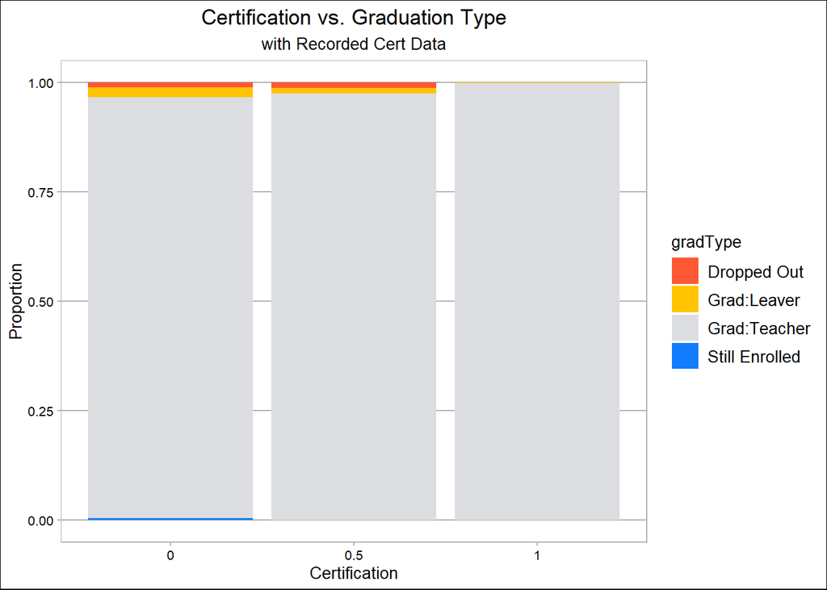

```r
# Define your custom color palette with hexadecimal color codes
custom_colors <- c("#FF5733", "#FFC300", "#dcdde0", "#127dff")

ggplot(main, aes(x = certification, fill = gradType)) +
  geom_bar(position = "fill") +
  scale_x_continuous(breaks = c(0, 0.5, 1), labels = c("0", "0.5", "1")) +
  labs(title = "Certification vs. Graduation Type", subtitle = "with Recorded Cert Data", x = "Certification", y = "Proportion", legend = "Graduated") +
  scale_fill_manual(values = custom_colors) +
  theme_calc() +
  theme(plot.title = element_text(hjust = 0.5),
        plot.subtitle = element_text(hjust = 0.5))
```

### Additional Education Requirements

Following the BYUI guidelines, there are other aspects to consider before completing the Teacher Preparation Program, such as:

- `GPA` of 2.5 minimum.
- `Disposition` Ratings
- `Praxis Exam`
- `Educator Technology certification`
- `Literacy Exams`
- `Student Teaching Preparation`
- `Background Check`
- `Proof of Performance`

### GPA Requirement: Minimum 2.5 GPA

Summary of `currentCumGPA` values:

- students: number of students
- avg_gpa: average GPA by certification status
- min_value, Q1, median, Q3, max_value: quartiles and extreme points
- failed_req: students that did not meet the 2.5 GPA minimum requirement
- met_req: students that did meet the 2.5 GPA minimum requirement

```r
# Summarise.
main|>
  group_by(certification) |>
  summarise(
    students = n(),
    avg_gpa = round(mean(CurrentCumGPA), 1),
    min_value = min(CurrentCumGPA),
    Q1 = quantile(CurrentCumGPA, 0.25),
    median = median(CurrentCumGPA),
    Q3 = quantile(CurrentCumGPA, 0.75),
    max_value = max(CurrentCumGPA),
    failed_req = sum(ifelse(CurrentCumGPA < 2.5, 1, 0)),
    met_req = sum(ifelse(CurrentCumGPA >= 2.5, 1, 0))
  ) |> pander()
```

Table continues below

| certification | students | avg_gpa | min_value | Q1 | median | Q3 |
| --- | --- | --- | --- | --- | --- | --- |
| 0 | 271 | 3.4 | 2.1 | 3.1 | 3.4 | 3.7 |
| 0.5 | 77 | 3.3 | 2.3 | 2.9 | 3.3 | 3.6 |
| 1 | 3655 | 3.5 | 2 | 3.3 | 3.6 | 3.8 |

| max_value | failed_req | met_req |
| --- | --- | --- |
| 4 | 4 | 267 |
| 4 | 2 | 75 |
| 4 | 35 | 3620 |

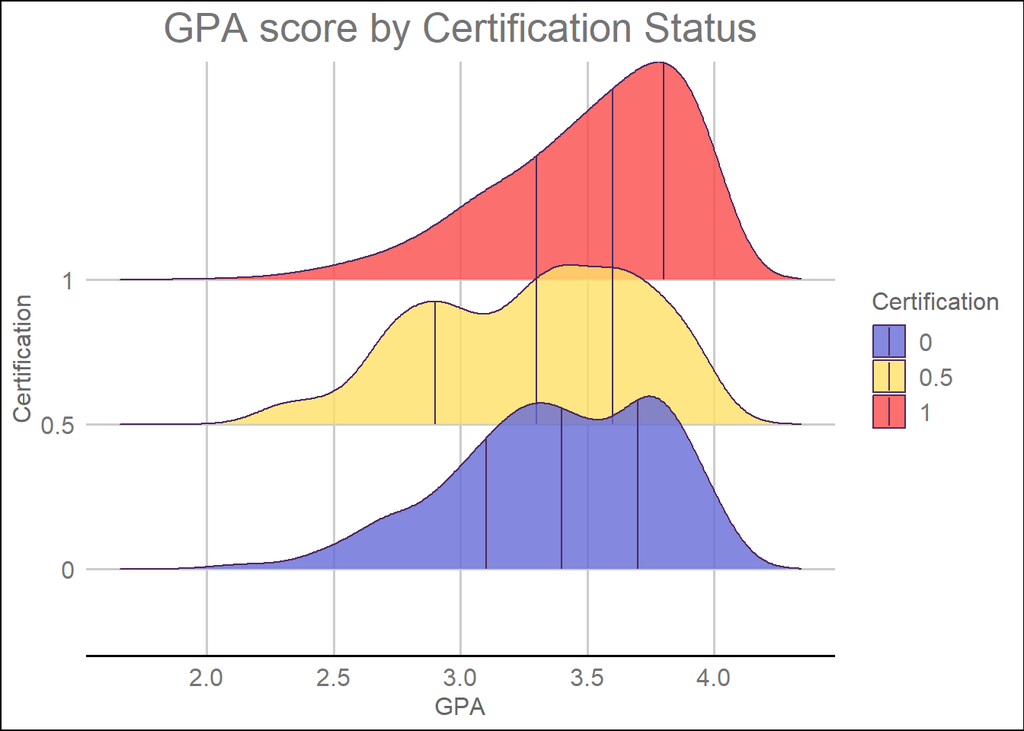

```r
# Graph.
ggplot(main, aes(x = CurrentCumGPA, y = as.factor(certification), fill = as.factor(certification))) +
  geom_density_ridges(scale = 1.5,quantile_lines = TRUE, alpha = 0.8, color = "#4e2a5e") +
  scale_fill_manual(values = c("0" = "#656ad6", "0.5" = "#ffe066", "1" = "#fa4b4b")) +
  theme_gdocs() +
 labs(fill = "Certification",
      x = "GPA",
      y = "Certification",
      title = "GPA score by Certification Status") +
  theme(plot.title = element_text(hjust = 0.5))
```

Initial linear model.

```r
# Create linear model.
lm_model <- lm(certification ~ CurrentCumGPA, data = main)
# Summary .
pander(summary(lm_model))
```

|  | Estimate | Std. Error | t value | Pr(>\|t\|) |
| --- | --- | --- | --- | --- |
| **(Intercept)** | 0.6765 | 0.0378 | 17.9 | 5.812e-69 |
| **CurrentCumGPA** | 0.0703 | 0.01073 | 6.551 | 6.421e-11 |

Fitting linear model: certification ~ CurrentCumGPA

| Observations | Residual Std. Error | $R^2$ | Adjusted $R^2$ |
| --- | --- | --- | --- |
| 4003 | 0.2566 | 0.01061 | 0.01037 |

Modify and create a logistic model, in where `certification` changes to 1 if the student successfully passed the program and 0 for any other answers.

```r
# Change certification to show 1 if the actually certified and other results as not finishing the program(0).
main <- main |>
  mutate(finished = ifelse(certification == 1, 1, 0))
# Create model.
glm_model <- glm(as.factor(finished) ~ CurrentCumGPA, data = main, family = binomial)
# Summary
pander(summary(glm_model))
```

|  | Estimate | Std. Error | z value | Pr(>\|z\|) |
| --- | --- | --- | --- | --- |
| **(Intercept)** | -0.9767 | 0.4632 | -2.109 | 0.03498 |
| **CurrentCumGPA** | 0.9668 | 0.136 | 7.11 | 1.161e-12 |

(Dispersion parameter for binomial family taken to be 1 )

| Null deviance: | 2365 on 4002 degrees of freedom |
| --- | --- |
| Residual deviance: | 2317 on 4001 degrees of freedom |

### Disposition Requirement: Ratings

Disposition scores are characterized as instructor-based ratings that focus on the student’s teaching knowledge and classroom professionalism. For more information regarding the Disposition assessment and the process of cleaning, as well as a full summary, please click [here.](https://thatdarls.github.io/DispositionOverview.html)

Summary of `Disposition_avg` values:

- students: number of students
- avg_disp: average disposition score by certification status
- min_value, Q1, median, Q3, max_value: quartiles and extreme points

```r
# Summarise.

main %>%
  filter(!is.na(Disposition_avg)) %>%
  group_by(certification) %>%
  summarise(
    students = n(),
    avg_disp = round(mean(Disposition_avg), 3),
    min_value = min(Disposition_avg),
    Q1 = quantile(Disposition_avg, 0.25, na.rm = TRUE),
    median = median(Disposition_avg, na.rm = TRUE),
    Q3 = quantile(Disposition_avg, 0.75, na.rm = TRUE),
    max_value = max(Disposition_avg)
  ) %>%
  pander()
```

Table continues below

| certification | students | avg_disp | min_value | Q1 | median | Q3 |
| --- | --- | --- | --- | --- | --- | --- |
| 0 | 70 | -0.044 | -1.375 | -0.342 | -0.071 | 0.2925 |
| 0.5 | 16 | 0.099 | -0.326 | -0.1058 | -0.0495 | 0.1125 |
| 1 | 1263 | 0.118 | -2.675 | -0.219 | 0.118 | 0.422 |

| max_value |
| --- |
| 1.793 |
| 1.793 |
| 3.048 |

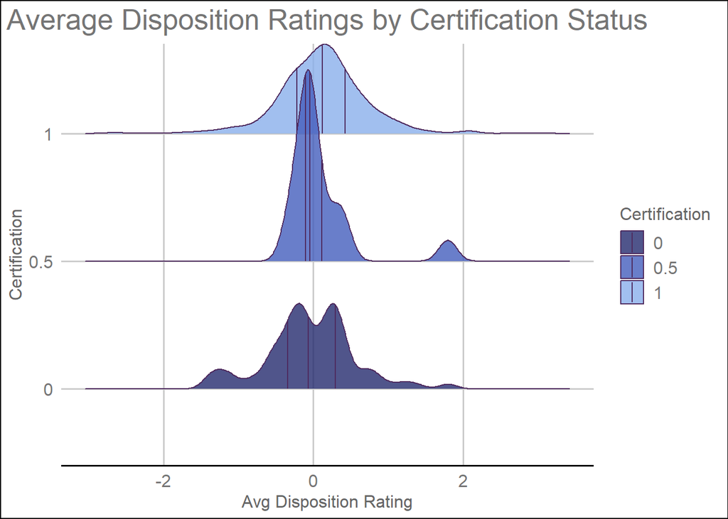

```r
# Graph.
ggplot(main, aes(x = Disposition_avg, y = as.factor(certification), fill = as.factor(certification))) +
  geom_density_ridges(scale = 1.5,quantile_lines = TRUE, alpha = 0.8, color = "#4e2a5e") +
  scale_fill_manual(values = c("0" = "#242b6e", "0.5" = "#445ebd", "1" = "#8aafeb")) +
  theme_gdocs() +
 labs(fill = "Certification",
      x = "Avg Disposition Rating",
      y = "Certification",
      title = "Average Disposition Ratings by Certification Status") +
  theme(plot.title = element_text(hjust = 0.5))
```

Initial linear model.

```r
# Create linear model.
lm_model2 <- lm(certification ~ Disposition_avg, data = main)
# Summary .
pander(summary(lm_model2))
```

|  | Estimate | Std. Error | t value | Pr(>\|t\|) |
| --- | --- | --- | --- | --- |
| **(Intercept)** | 0.9396 | 0.006279 | 149.6 | 0 |
| **Disposition_avg** | 0.02351 | 0.01058 | 2.223 | 0.02638 |

Fitting linear model: certification ~ Disposition_avg

| Observations | Residual Std. Error | $R^2$ | Adjusted $R^2$ |
| --- | --- | --- | --- |
| 1349 | 0.2267 | 0.003655 | 0.002915 |

Modify and create a logistic model, in where `certification` changes to 1 if the student successfully passed the program and 0 for any other answers.

```r
# Certification shows 1 if the actually certified and other results as not finishing the program(0).
# Create model.
glm_model2 <- glm(as.factor(finished) ~ Disposition_avg, data = main, family = binomial)
# Summary
pander(summary(glm_model2))
```

|  | Estimate | Std. Error | z value | Pr(>\|z\|) |
| --- | --- | --- | --- | --- |
| **(Intercept)** | 2.667 | 0.1116 | 23.89 | 3.905e-126 |
| **Disposition_avg** | 0.3918 | 0.1875 | 2.09 | 0.03661 |

(Dispersion parameter for binomial family taken to be 1 )

| Null deviance: | 639.9 on 1348 degrees of freedom |
| --- | --- |
| Residual deviance: | 635.6 on 1347 degrees of freedom |

### Praxis Exam Requirement: State Passing Scores

Praxis score is used to assess the knowledge and skill level for each student and is required for those seeking an Education major or minor. Each test has a mandated state passing score that every student must pass in order to continue with the Teaching Program.

Summary of `Praxis` values:

- Test_Name: name of test
- n: number of entries per test
- avg_prax_score: overall average praxis score per test
- pass_rate: passing rate for each test

```r
# Select only the required columns.
praxscore <- praxis |>
  mutate(StudentID = as.character(StudentID)) |>
  select(StudentID, Test_Name, Test_Code, Last_Score, State_Pass_Score)
# Create new df with Praxis scores.
main2 <- main |>
  left_join(praxscore, by = "StudentID")

# Summarise.
main2 |>
  group_by(Test_Name) |>
  summarise(n = n(),
            avg_prax_score = mean(Last_Score, na.rm = TRUE),
            pass_rate = sprintf("%.2f%%", sum(ifelse(!is.na(Last_Score) & !is.na(State_Pass_Score), Last_Score >=    State_Pass_Score, FALSE)) / n * 100)) |>
  arrange(desc(n)) |>
  pander()
```

| Test_Name | n | avg_prax_score | pass_rate |
| --- | --- | --- | --- |
| 5003 Elem Ed: MS Mathematics Subtest | 1289 | 178.4 | 97.44% |
| 5005 Elem Ed: MS Science Subtest | 1284 | 174.4 | 97.74% |
| 5004 Elem Ed: MS Social Studies Subtest | 1283 | 170.4 | 97.43% |
| 5002 Elem Ed: MS Reading & Language Arts Subtest | 1280 | 174 | 98.75% |
| NA | 412 | NA | 0.00% |
| 5038 English Language Arts: Content Knowledge | 335 | 179.9 | 97.91% |
| 5047 Middle School English Language Arts | 330 | 167.3 | 84.85% |
| 5622 Principles of Learn & Teaching: Grades K-6 | 329 | 175.9 | 95.74% |
| 5691 Special Ed: Preschool/Early Childhood | 307 | 173.4 | 99.35% |
| 5941 World and US History: Content Knowledge | 246 | 164.6 | 99.19% |
| 5089 Middle School Social Studies | 223 | 165.8 | 96.41% |
| 5362 English to Speakers of Other Languages | 220 | 174.7 | 99.55% |
| 5025 Early Childhood Education | 214 | 176.7 | 100.00% |
| 5195 Spanish: World Language | 201 | 173.2 | 90.55% |
| 5134 Art: Content Knowledge | 187 | 166.6 | 97.86% |
| 5034 Elem Ed: MS Social Studies Subtest | 181 | 168.8 | 92.82% |
| 5033 Elem Ed: MS Mathematics Subtest | 179 | 175.2 | 84.36% |
| 5035 Elem Ed: MS Science Subtest | 178 | 175 | 95.51% |
| 5032 Elem Ed: MS Reading & Language Arts Subtest | 177 | 181.2 | 96.05% |
| 5169 Middle School Mathematics | 174 | 176.7 | 97.13% |
| 5543 Special Ed: Core Know Mild to Moderate App | 169 | 172.5 | 100.00% |
| 0014 Elem Ed: Content Knowledge | 156 | 170.6 | 95.51% |
| 0622 Principles of Learn & Teaching: Grades K-6 | 155 | 175.2 | 98.71% |
| 5113 Music: Content Knowledge | 154 | 169.9 | 100.00% |
| 5161 Mathematics: Content Knowledge | 154 | 168.9 | 91.56% |
| 5440 Middle School Science | 126 | 160.7 | 92.86% |
| 5235 Biology: Content Knowledge | 93 | 165.7 | 100.00% |
| 5022 Early Childhood: Content Knowledge | 90 | 180.4 | 97.78% |
| 0691 Special Ed: Preschool/Early Childhood | 87 | 175.3 | 96.55% |
| 5081 Social Studies: Content Knowledge | 77 | 174.2 | 100.00% |

[output cut: 87 more lines]

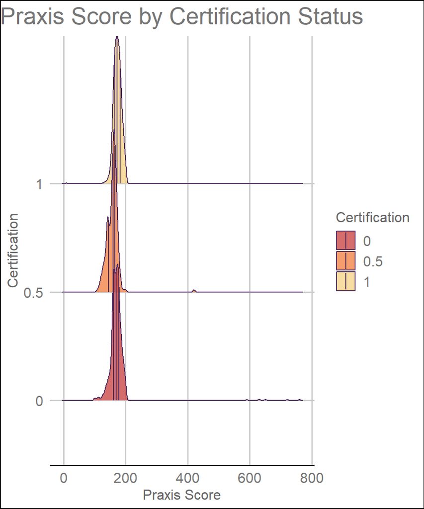

```r
# Graph.
ggplot(main2, aes(x = Last_Score, y = as.factor(certification), fill = as.factor(certification))) +
  geom_density_ridges(scale = 1.5,quantile_lines = TRUE, alpha = 0.8, color = "#4e2a5e") +
  scale_fill_manual(values = c("0" = "#c94947", "0.5" = "#f28449", "1" = "#f5d489")) +
  theme_gdocs() +
  labs(fill = "Certification",
       x = "Praxis Score",
       y = "Certification",
       title = "Praxis Score by Certification Status") +
  theme(plot.title = element_text(hjust = 0.5))
```

Initial linear model.

```r
# Create linear model.
lm_model3 <- lm(certification ~ Last_Score, data = main2)
# Summary .
pander(summary(lm_model3))
```

|  | Estimate | Std. Error | t value | Pr(>\|t\|) |
| --- | --- | --- | --- | --- |
| **(Intercept)** | 0.861 | 0.01252 | 68.76 | 0 |
| **Last_Score** | 0.0003378 | 7.037e-05 | 4.8 | 1.605e-06 |

Fitting linear model: certification ~ Last_Score

| Observations | Residual Std. Error | $R^2$ | Adjusted $R^2$ |
| --- | --- | --- | --- |
| 11337 | 0.2594 | 0.002029 | 0.001941 |

Modify and create a logistic model, in where `certification` changes to 1 if the student successfully passed the program and 0 for any other answers.

```r
# Certification shows 1 if the actually certified and other results as not finishing the program(0).
# Create model.
glm_model3 <- glm(as.factor(finished) ~ Last_Score, data = main2, family = binomial)
# Summary
pander(summary(glm_model3))
```

|  | Estimate | Std. Error | z value | Pr(>\|z\|) |
| --- | --- | --- | --- | --- |
| **(Intercept)** | -1.439 | 0.3597 | -4 | 6.342e-05 |
| **Last_Score** | 0.02178 | 0.002116 | 10.29 | 7.48e-25 |

(Dispersion parameter for binomial family taken to be 1 )

| Null deviance: | 6982 on 11336 degrees of freedom |
| --- | --- |
| Residual deviance: | 6863 on 11335 degrees of freedom |

### Educator Technology Certification

Students will receive a [Google Educator Level 1 Certification](https://edu.google.com/for-educators/overview/?modal_active=none) before student teaching, although there’s no data provided to see if it’s a significant variable or not, thus will not be included.

### Literacy Exam Requirement

Students must pass the Idaho Comprehensive Literacy exams with a minimum score of 70% and above before student teaching. We don’t have the data needed for analysis, thus will not be included.

### Student Teaching Preparation

Preparation of resume and cover letter. Information not provided for analysis.

### Background Check

Required for entering schools. Information not provided for analysis.

### Proof of Performance

Otherwise known as *Danielson Framework for Teaching*, it is a framework that breaks down a candidate’s performance and knownledge, based on a 4(Effective) to 1(Minimally Ineffective) scoring.

Summary of `WDanielson_highest_level` values:

- students: number of students
- avg_dan_score: average Danielson score by certification status
- min_value, Q1, median, Q3, max_value: quartiles and extreme points

```r
# Summary.
main |>
  group_by(certification) |>
  summarise(
    students = n(),
    avg_dan_score = round(mean(WDanielson_highest_level, na.rm = TRUE), 3),
    min_value = min(WDanielson_highest_level, na.rm = TRUE),
    Q1 = quantile(WDanielson_highest_level, 0.25, na.rm = TRUE),
    median = median(WDanielson_highest_level, na.rm = TRUE),
    Q3 = quantile(WDanielson_highest_level, 0.75, na.rm = TRUE),
    max_value = max(WDanielson_highest_level, na.rm = TRUE)) |>
  pander()
```

Table continues below

| certification | students | avg_dan_score | min_value | Q1 | median |
| --- | --- | --- | --- | --- | --- |
| 0 | 271 | -0.048 | -3.277 | -0.386 | 0.305 |
| 0.5 | 77 | 0.242 | -2.146 | 0.2575 | 0.5445 |
| 1 | 3655 | -0.001 | -5.23 | -0.4152 | 0.317 |

| Q3 | max_value |
| --- | --- |
| 0.57 | 1.468 |
| 0.6558 | 0.695 |
| 0.584 | 2.503 |

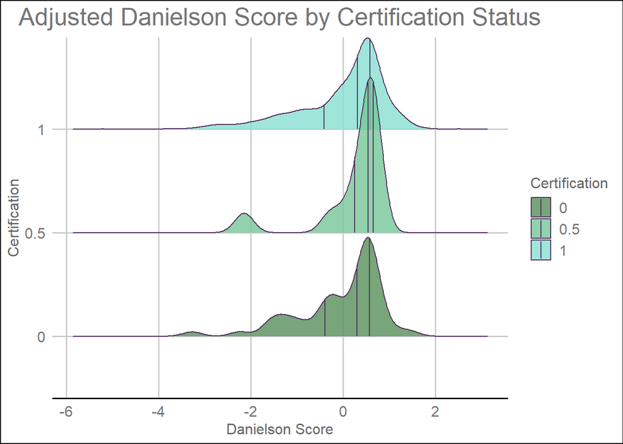

```r
# Graph.
ggplot(main, aes(x = WDanielson_highest_level, y = as.factor(certification), fill = as.factor(certification))) +
  geom_density_ridges(scale = 1.5,quantile_lines = TRUE, alpha = 0.8, color = "#4e2a5e") +
  scale_fill_manual(values = c("0" = "#568f58", "0.5" = "#75c799", "1" = "#87ded1")) +
  theme_gdocs() +
 labs(fill = "Certification",
      x = "Danielson Score",
      y = "Certification",
      title = "Adjusted Danielson Score by Certification Status") +
  theme(plot.title = element_text(hjust = 0.5))
```

Initial linear model.

```r
# Create linear model.
lm_model4 <- lm(certification ~ WDanielson_highest_level, data = main)
# Summary .
pander(summary(lm_model4))
```

|  | Estimate | Std. Error | t value | Pr(>\|t\|) |
| --- | --- | --- | --- | --- |
| **(Intercept)** | 0.9351 | 0.007955 | 117.6 | 0 |
| **WDanielson_highest_level** | 0.001313 | 0.008401 | 0.1563 | 0.8758 |

Fitting linear model: certification ~ WDanielson_highest_level

| Observations | Residual Std. Error | $R^2$ | Adjusted $R^2$ |
| --- | --- | --- | --- |
| 909 | 0.2398 | 2.693e-05 | -0.001076 |

Modify and create a logistic model, in where `certification` changes to 1 if the student successfully passed the program and 0 for any other answers.

```r
# Certification shows 1 if the actually certified and other results as not finishing the program(0).
# Create model.
glm_model4 <- glm(as.factor(finished) ~ WDanielson_highest_level, data = main2, family = binomial)
# Summary
pander(summary(glm_model4))
```

|  | Estimate | Std. Error | z value | Pr(>\|z\|) |
| --- | --- | --- | --- | --- |
| **(Intercept)** | 2.22 | 0.06172 | 35.97 | 2.681e-283 |
| **WDanielson_highest_level** | -0.002915 | 0.06605 | -0.04414 | 0.9648 |

(Dispersion parameter for binomial family taken to be 1 )

| Null deviance: | 1904 on 2969 degrees of freedom |
| --- | --- |
| Residual deviance: | 1904 on 2968 degrees of freedom |

### Test Models

#### First Model: CurrentCumGPA + WDanielson_highest_level + Disposition_avg + Last_Score

```r
# Model
lm_model5 <- lm(certification ~ CurrentCumGPA + WDanielson_highest_level + Disposition_avg + Last_Score, data = main2)
# Summary
pander(summary(lm_model5))
```

|  | Estimate | Std. Error | t value | Pr(>\|t\|) |
| --- | --- | --- | --- | --- |
| **(Intercept)** | -0.04659 | 0.06218 | -0.7492 | 0.4538 |
| **CurrentCumGPA** | 0.1287 | 0.01423 | 9.045 | 2.647e-19 |
| **WDanielson_highest_level** | -0.007678 | 0.00527 | -1.457 | 0.1453 |
| **Disposition_avg** | -0.00909 | 0.01265 | -0.7185 | 0.4725 |
| **Last_Score** | 0.002959 | 0.0002909 | 10.17 | 6.51e-24 |

Fitting linear model: certification ~ CurrentCumGPA + WDanielson_highest_level + Disposition_avg + Last_Score

| Observations | Residual Std. Error | $R^2$ | Adjusted $R^2$ |
| --- | --- | --- | --- |
| 2957 | 0.2581 | 0.08339 | 0.08215 |

#### Second Model: CurrentCumGPA + WDanielson_highest_level + Last_Score

```r
# Model
lm_model6 <- lm(certification ~ CurrentCumGPA + WDanielson_highest_level + Last_Score, data = main2)
# Summary
pander(summary(lm_model6))
```

|  | Estimate | Std. Error | t value | Pr(>\|t\|) |
| --- | --- | --- | --- | --- |
| **(Intercept)** | -0.04524 | 0.05855 | -0.7726 | 0.4398 |
| **CurrentCumGPA** | 0.1249 | 0.01252 | 9.98 | 4.298e-23 |
| **WDanielson_highest_level** | -0.007786 | 0.00517 | -1.506 | 0.1322 |
| **Last_Score** | 0.003013 | 0.0002931 | 10.28 | 2.269e-24 |

Fitting linear model: certification ~ CurrentCumGPA + WDanielson_highest_level + Last_Score

| Observations | Residual Std. Error | $R^2$ | Adjusted $R^2$ |
| --- | --- | --- | --- |
| 2962 | 0.2602 | 0.08402 | 0.0831 |

#### Third Model: CurrentCumGPA + Last_Score

```r
# Model
lm_model7 <- lm(certification ~ CurrentCumGPA + Last_Score, data = main2)
# Summary
pander(summary(lm_model7))
```

|  | Estimate | Std. Error | t value | Pr(>\|t\|) |
| --- | --- | --- | --- | --- |
| **(Intercept)** | 0.6048 | 0.02485 | 24.34 | 1.49e-127 |
| **CurrentCumGPA** | 0.07705 | 0.006468 | 11.91 | 1.591e-32 |
| **Last_Score** | 0.0002533 | 7.029e-05 | 3.604 | 0.0003148 |

Fitting linear model: certification ~ CurrentCumGPA + Last_Score

| Observations | Residual Std. Error | $R^2$ | Adjusted $R^2$ |
| --- | --- | --- | --- |
| 11337 | 0.2578 | 0.01437 | 0.0142 |

#### Fourth Model: CurrentCumGPA + Last_Score + Disposition_avg

```r
# Model
lm_model8 <- lm(certification ~ CurrentCumGPA + Last_Score + Disposition_avg, data = main2)
# Summary
pander(summary(lm_model8))
```

|  | Estimate | Std. Error | t value | Pr(>\|t\|) |
| --- | --- | --- | --- | --- |
| **(Intercept)** | 0.03109 | 0.04924 | 0.6313 | 0.5279 |
| **CurrentCumGPA** | 0.09769 | 0.0103 | 9.485 | 3.846e-21 |
| **Last_Score** | 0.003204 | 0.0002471 | 12.97 | 9.044e-38 |
| **Disposition_avg** | -0.01406 | 0.007049 | -1.995 | 0.0461 |

Fitting linear model: certification ~ CurrentCumGPA + Last_Score + Disposition_avg

| Observations | Residual Std. Error | $R^2$ | Adjusted $R^2$ |
| --- | --- | --- | --- |
| 4451 | 0.2451 | 0.07074 | 0.07011 |

#### Fifth Model: CurrentCumGPA + Last_Score + isMale

```r
# Model
lm_model9 <- lm(certification ~ CurrentCumGPA + Last_Score + isMale, data = main2)
# Summary
pander(summary(lm_model9))
```

|  | Estimate | Std. Error | t value | Pr(>\|t\|) |
| --- | --- | --- | --- | --- |
| **(Intercept)** | 0.5907 | 0.02528 | 23.36 | 6.049e-118 |
| **CurrentCumGPA** | 0.08045 | 0.006564 | 12.26 | 2.582e-34 |
| **Last_Score** | 0.0002509 | 7.027e-05 | 3.571 | 0.0003569 |
| **isMale** | 0.02398 | 0.007998 | 2.998 | 0.002725 |

Fitting linear model: certification ~ CurrentCumGPA + Last_Score + isMale

| Observations | Residual Std. Error | $R^2$ | Adjusted $R^2$ |
| --- | --- | --- | --- |
| 11337 | 0.2577 | 0.01515 | 0.01489 |